# Modeling the growth of non-decomposed municipal solid waste in US landfills

## Introduction

Municipal solid waste (MSW) - commonly known as trash or garbage - is often disposed in landfills. In the United States, 52% of MSW generated in 2017 was landfilled - amounting to 127 million metric tons. The remaining MSW was either recycled (25%), combusted (13%), or composted (10%) [1]. The ten MSW materials labeled by the EPA are paper, food, yard trimmings, wood, steel, rubber and leather, textiles, aluminum, plastic, and glass. It is often an environmental concern that if certain MSW materials require a substantial amount of time to decompose, then large amounts of land area and volume would be occupied by those non-decomposed MSW materials in future landfills. Such a scenario could potentially have disruptive effects on ecosystems and reduce land availability for society at large. It is therefore important to have a model that provides an estimate of the decomposed and - more importantly - non-decomposed amount of each MSW material in landfills over time.

Such a model would require a number of inputs: Firstly, the amount of each MSW material landfilled, for both past and future years. Secondly, the decomposition functions for each MSW material. Thirdly, densities of each MSW material to calculate the volume occupied by the non-decomposed MSW material. Finally, mean landfill depth to calculate the theoretical amount of land area occupied by the non-decomposed MSW material. This notebook uses the terms ‘added to landfills’ and ‘landfilled’ interchangeably. The amount of each MSW material landfilled annually is available from the EPA at various time-intervals since 1960. The totals across all MSW materials for this data is shown in Figure 1.

While the amount of each MSW material landfilled in previous years is available, the amount of each MSW material landfilled in future years needs to be assumed. Annual MSW landfill additions increased rapidly between 1960 and 1990, but roughly flattened since then (Fig. 1). This can partly be explained by the rise in the rate of recycling and composting, which increased from 10% of MSW generated in 1985 to 34% of MSW generated in 2010. However, the rate of recycling and composting has remained flat since 2010 [1]. A full explanation of the plateau in annual MSW landfill additions since 1990 is made clear by trends in annual MSW generation per capita, which has remained roughly flat at 0.75 metric tons per person per year (Fig 2.). Therefore, flattening of MSW landfill additions over the last two decades can be attributed to the flattening of MSW generation, whether it is landfilled, recycled, combusted, or composted. Such a flattening could be attributed to the Jevons paradox, in which increases in efficiency are counterbalanced by increases in consumption such that the total production level remains roughly flat [3]. It is not unreasonable to assume that such a trend would continue in future years. MSW generation per capita cannot increase indefinitely and is likely to plateau at some point as consumers face diminishing marginal utility in MSW generation. Whether the plateau in MSW generation per capita has been reached is open to debate.

[figure not shown]

Figure 1. The totals across all named MSW materials landfilled in the United States for each of the available years from 1960 to 2017. Unnamed ‘other’ materials of MSW representing less than 5% of total MSW landfill additions are not included in the totals shown here. [2]

[figure not shown]

Figure 2. The amount of MSW generated per person per year in the United States for each of the available years from 1960 to 2017. [1]

The precise decomposition functions over time for each of the MSW materials is either not generally known or has a high degree of uncertainty. There is evidence that the decomposition of plastics follows a function similar to an exponential decay with a steep negative slope early on that gradually flattens while still remaining negative [7]. However, it is not generally known what the decomposition functions are for other MSW materials. Exponential decay, which results from the decay rate being directly proportional to the amount of material, seems to be the most elemental function of decomposition without being over simplistic:

$$\frac{dN}{dt} = -kN$$

If exponential decay is the best estimate under uncertainty for the structure of the decomposition functions for each of the MSW materials, it remains to be known what the decay constant, k is for the various MSW materials. These can be estimated using the decomposition times provided by a variety of sources. Estimates for the decomposition times of food, rubber and leather, textiles, aluminum, and glass can be obtained from the Mote Marine Lab [4]. An estimate for the decomposition time of paper in landfills is provided by Ximenes [5]. An estimate for the decomposition time of wood products in landfills can be calculated by the measured loss of wood products’ original carbon content in landfills provided by Ximenes et al. [6]. Commonly quoted decomposition times and estimates based on similar materials can be used for yard trimmings, steel, and plastic. Because exponential decay functions never reach zero, there must be a declared 'percent remaining' at the point of the decomposition time. Here, I use the relatively conservative number of 5%. That is, at the decompsition time for the MSW material, 5% is still remaining to decompose. The decomposition functions are likely the greatest source of uncertainty in any model of non-decomposed MSW material in landfills over time.

The densities of certain baled or compressed MSW materials can be obtained from the volume to weight conversions provided by the EPA [8]. Estimates of the density of wood in landfills is provided by Ximenes et al. [6]. For other MSW materials such as rubber and leather, and glass, densities can be obtained from the standard widely available measurements. In some cases, the volume to weight conversions provided by the EPA are only available for a limited number of instances of a MSW material. For example, baled aluminum cans is the only provided density by the EPA of the MSW material aluminum. In those cases, an average can be made between the standard widely available density of that MSW material and the EPA provided density. This is required for steel and aluminum, which have limited measurements provided by the EPA. An average of the MSW material densities - weighted by the amount of their most recent annual landfill - can be compared to the overall density of MSW material provided by the EPA in order to verify its reliability.

Mean landfill depth in the United States can be obtained from the median depth of the 2,549 landfills in the EPA’s Landfill Methane Outreach Program (LMOP) database. While the LMOP database does not contain information on every landfill in the United States, it is the most comprehensive dataset available. The medians for the current and design landfill depth are 24.1 and 25.9 meters, respectively. The 25th and 75th percentiles are 15.2 and 33.4 meters for the current landfill depth, and 16.8 and 39.6 meters for the design landfill depth [9].

The goal here is to present the results of creating model using the inputs described above to simulate the growth in the total amount of decomposed and non-decomposed material in landfills in the United States over time. The model constructed uses the specific inputs described above but can accommodate any decomposition function for each MSW material (not only exponential decay), and can accommodate any function over time for the annual additions of each MSW material. It is important to note that such a model can be applied to landfills for other nations or groups of nations. The model was applied to the United States because of the availability and reliability of EPA data. While the particular simulation described here suffers from large uncertainties, especially in the decomposition functions for the MSW materials, the goal is to provide a base estimate with the most reliable data available.

## Example Of Aluminum

As an example, here we can see the exponential decay of the MSW material aluminum from **one** year. We start with the initial 2.4 million metric tons added that year, and the amount from that year then decays over time, where we round to zero after about 480 years of decomposition.

```python
import landfill as lf
```

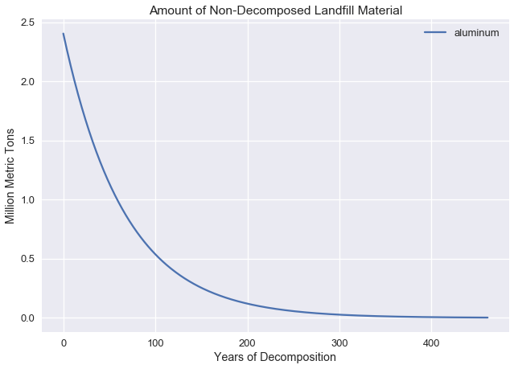

```python
lf.plot_reference_list(7)
```

However, to get the total amount of aluminum in landfills we have to consider the annual annual additions of aluminum into landfills that continue indefinitely. Using annual additions of 2.4 million metric tons each year, with each addition decomposing as just described, we get this:

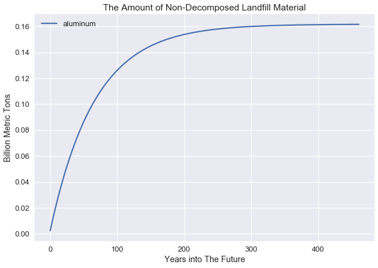

```python
lf.plot_curve_list(7)
```

## Results

### From 1960 to 2017

This plot shows the total amount of non-decomposed MSW for each material using the real EPA data of annual additions from 1960 to 2017, and the decomposition functions described earlier. The MSW types are ordered from most to least at the end, thus, the MSW type with the most amount of non-decomposed material in US landfills is plastic, the MSW type with the least is yard trimmings.

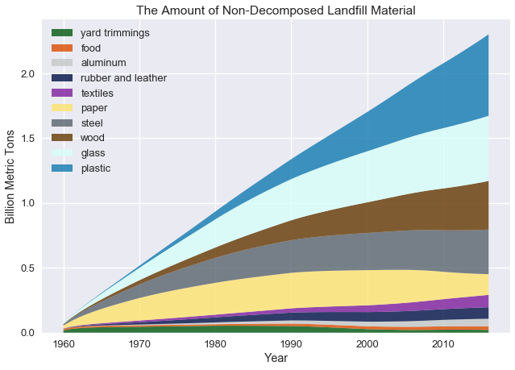

```python
lf.stack_plot_all_curve_lists(start_year=1960, stop_year=2017, no_decomposition=False)
```

This can be compared to the amount of decomposed *and* non-decomposed lanfill material. Here we see that the most amount of landfill material is paper (both decomposed and non-decomposed) whereas plastic is much lower. You can also see that non-decomposed material is about 1/3 of all material (2/3's have decomposed).

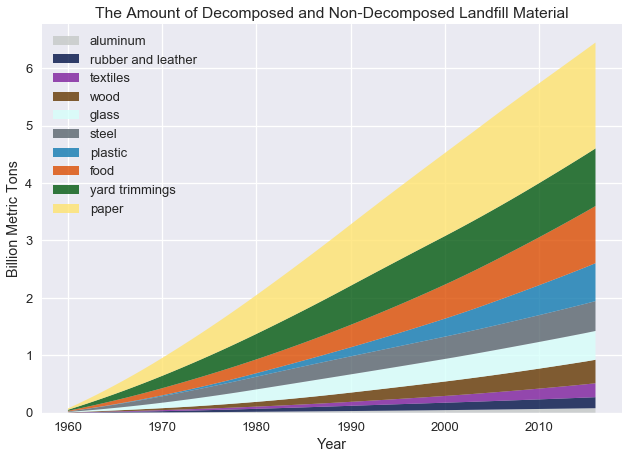

```python
lf.stack_plot_all_curve_lists(start_year=1960, stop_year=2017, no_decomposition=True)
```

Here we can see the same two plots as before but as percentages rather than value amounts.

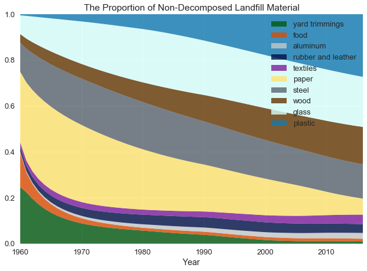

```python
lf.percent_stack_area(start_year=1960, stop_year=2017, no_decomposition=False)
```

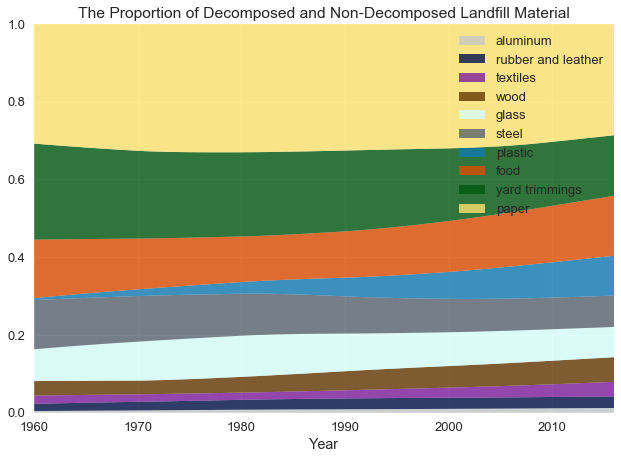

```python
lf.percent_stack_area(start_year=1960, stop_year=2017, no_decomposition=True)
```

### From 1960 to 2100

This is cool, but we have the potential to go much farther into time. Let's assume that annual additions of each MSW type will remain constant (the justification for this assumption was stated earlier). Let's take a look at up to the year 2100.

This is the amount of non-decomposed MSW material for each waste type going up to the year 2100. We can see some interesting trends. Paper tends to go up, then down, and then steady off. Plastic, wood, and glass seem to be driving the long-term upward trajectory.

#### Non-Decomposed Mass

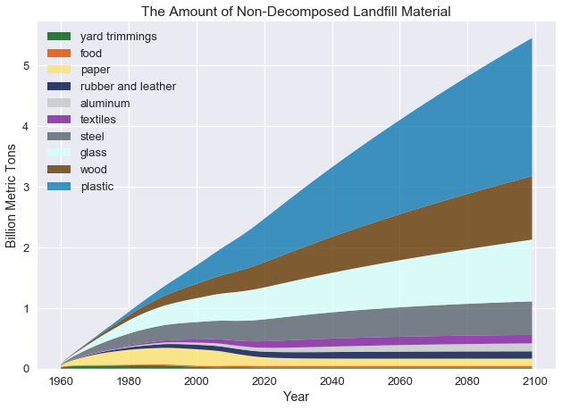

```python
lf.stack_plot_all_curve_lists(start_year=1960, stop_year=2100, no_decomposition=False)
```

We've just been using mass as the measurement, but knowing the density of each MSW material, we can get the volume occupied by each non-decomposed MSW material. We can see here that in terms of volume occupied, most seems to be due to plastic, perhaps because it is not very dense.

#### Non-Decomposed Volume

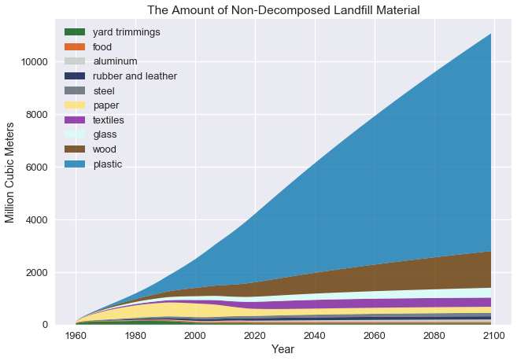

```python
lf.stack_plot_all_curve_lists(start_year=1960, stop_year=2100, calculation='volume', no_decomposition=False)
```

#### Non-Decomposed Land Area

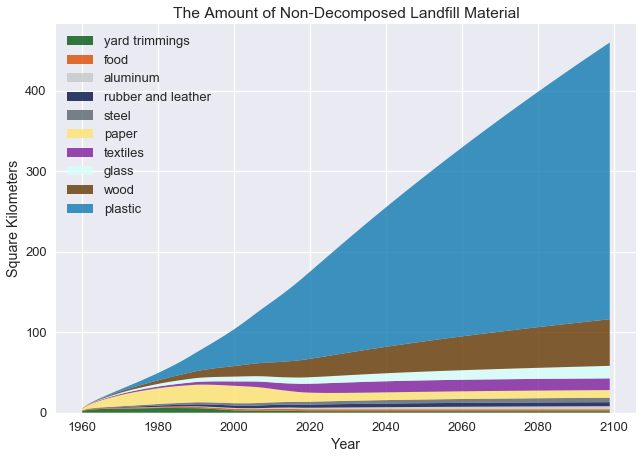

```python
lf.stack_plot_all_curve_lists(start_year=1960, stop_year=2100, calculation='area', no_decomposition=False)
```

Let's see the projected land area occupied by both decomposed and non-decomposed MSW material. Here we see that it gets up to 16,000 square kilometers, which is like a square that's 126 km on a side. Also, food, and yard trimmings are occupying way more land area, presumeably because they have high added amounts but low decomposition times.

#### Non-Decomposed and Decomposed Land Area

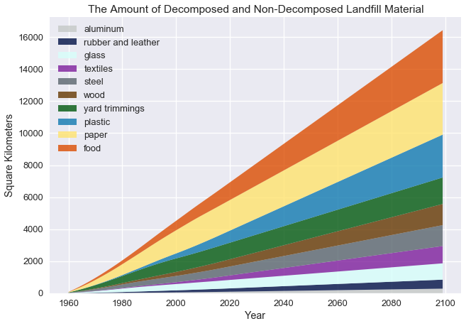

```python
lf.stack_plot_all_curve_lists(start_year=1960, stop_year=2100, calculation='area', no_decomposition=True)
```

### From 1960 to Equilibrium

Okay, but what about steady state, or is there a steady state? In other words, if the US keeps adding the same amount of each MSW type to landfills indefinitely. Will there be a point at which the amount of annual additions equals the amount of annual decomposition and the total amount of non-decomposed MSW material stays the same. If that exists, how much MSW material would there be?

#### Non-Decomposed Mass

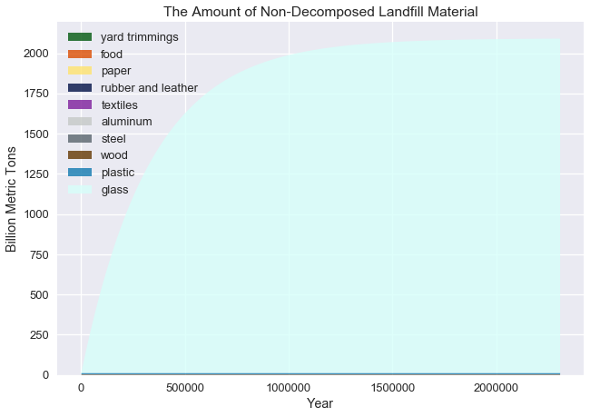

```python
lf.stack_plot_all_curve_lists(start_year=1960, calculation='mass', no_decomposition=False)
```

This would take up about 33,000 square kilometers, which is a bit larger than the total land area of Massachusetts (27,000 sq km).

#### Non-Decomposed Land Area

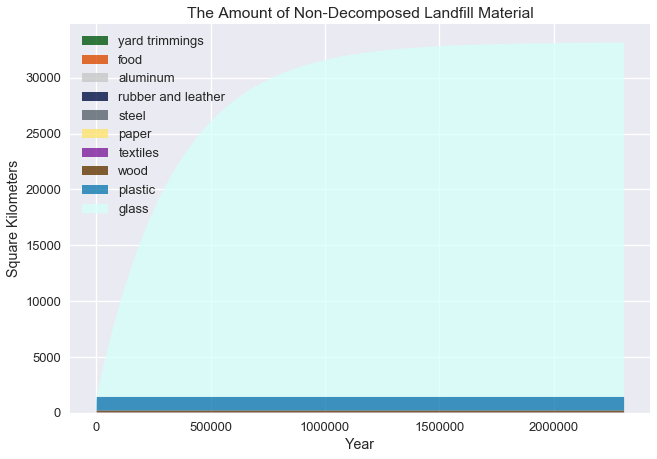

```python
lf.stack_plot_all_curve_lists(start_year=1960, calculation='area', no_decomposition=False)
```

### If the US stops landfilling glass in the year 2200

If, by some miracle, people decided to stop throwing away glass and recycle or combust for energy all glass waste, then let's see when and what the steady state amounts are.

Here we show what happens if in the year 2,200 the US stops landfilling glass. Steady state is reached at close to 14 billion metric tons around the year 4,300.

#### Non-Decomposed Mass

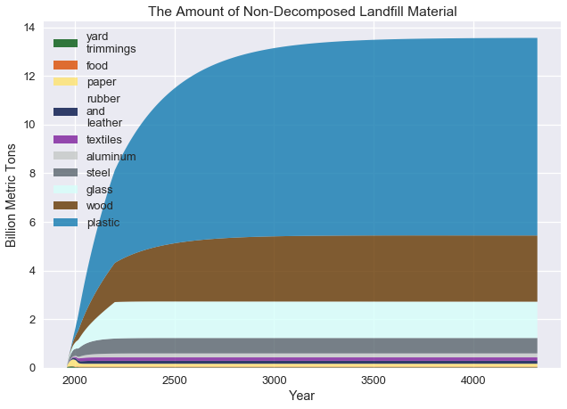

```python
lf.stack_plot_all_curve_lists(start_year=1960, stop_year=4323, calculation='mass', no_decomposition=False)
```

Expressed in terms of land area occupied, this is about 1,400 square kilometers, which is like a square 37 km on a side. It's also about half the size of Rhode Island (3,100 sq km).

#### Non-Decomposed Land Area

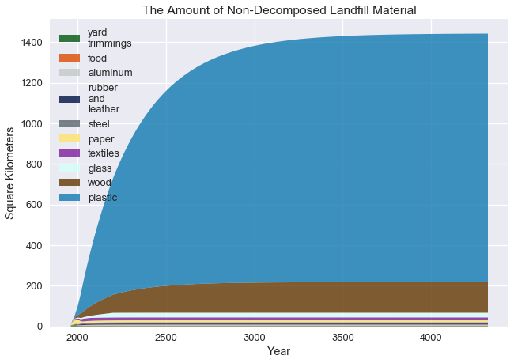

```python
lf.stack_plot_all_curve_lists(start_year=1960, stop_year=4323, calculation='area', no_decomposition=False)
```

To put the numbers about land area into perspective, consider that 515,000 square kilometers in the US are occupied by cropland for livestock feed [10], somewhat larger than the total land area of California (425,000 square kilometers).

## Discussion

We can try to explain the results we've seen by looking at the annual added amounts of each MSW type (using 2017 data) and the decomposition time for each MSW type. While glass has a relatively small annual addition amount of 6.23 million metric tons, it takes about 1,000,000 years to decompose. If glass continues to be put in landfills at the current amounts, most of the landfills of the future will be filled with glass, not plastic as commonly worried. Because while plastic has a factor of 4 greater annual additions, glass has a factor of 1000 greater decomposition time, which ends up winning. On the other hand, food and paper have high annual additions to landfills, but relatively short decomposition times. Thus, landfills of the far future will be filled with glass, rather than plastic. In addition, organic materials such as food, yard trimmings, and paper have an overall high annual contribution to landfills, but have low decompsition times, meaning they won't contribute much to the overall amount of non-decomposed material in the future.

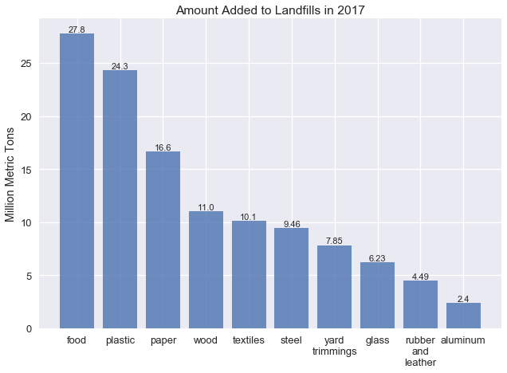

```python
lf.bar_chart_list(added_amounts, Sorted=True)
```

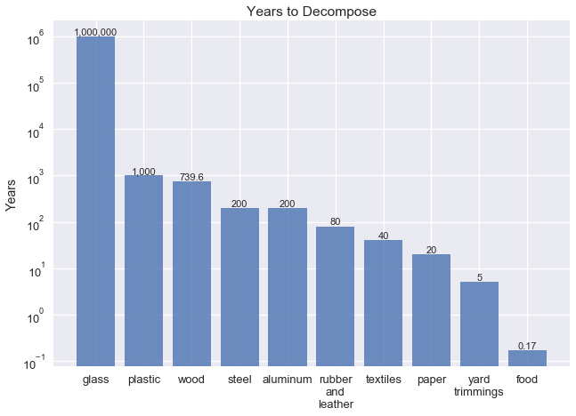

```python
lf.bar_chart_list(decomp_times, Sorted=True)
```

This graph shows the year at steady state for each of the MSW types on a logarithmic scale.

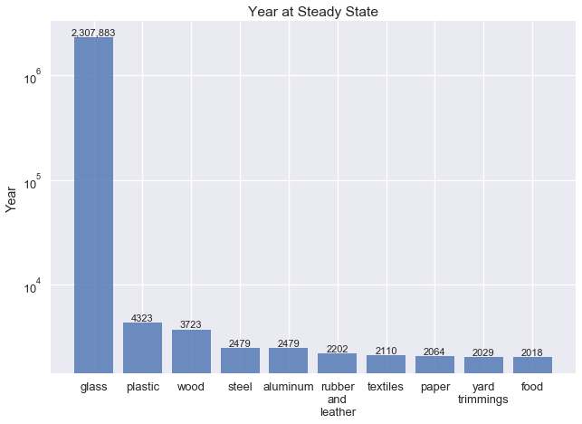

```python
lf.bar_chart_list(lf.steady_state_years(start_year=1960), Sorted=True)
```

These final two graphs show the amount of the MSW types at steady state for each on a logarithmic scale in terms of mass and land area.

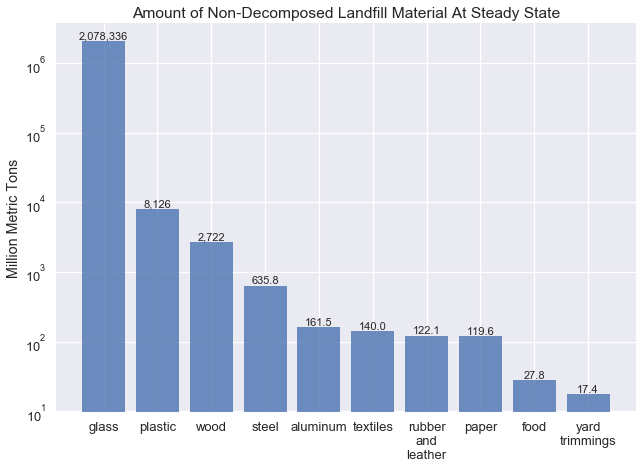

```python
lf.bar_chart_list(lf.steady_state_amounts(), Sorted=True)
```

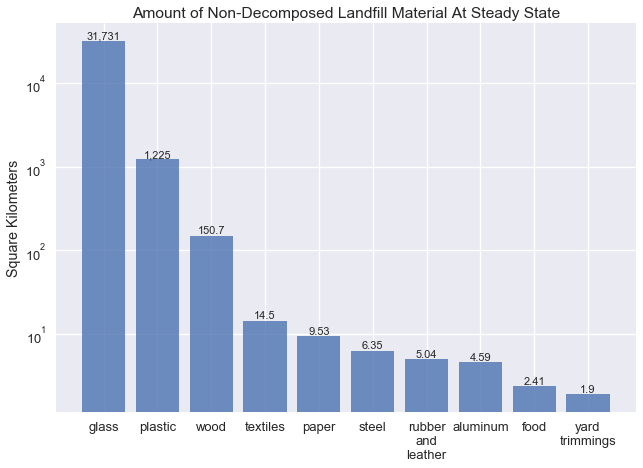

```python
lf.bar_chart_list(lf.steady_state_amounts(calculation='area'), Sorted=True)
```

In conclusion, I wanted to do this project because I wanted to know if the landfills of the future would ever reach an equilibrium point, and if so, how large would they be at that equilibrium. I took an hour or two and got a very rough idea on excel, but later once I learned python, I realized you could attempt to make a model as accurate as possible using the historical annual added amounts, decomposition times, the landfill densities specific to each MSW type, the median landfill density, and about 1,000 lines of code. I think understanding the total amount of non-decomposed landfill material may be important for setting environmental priorities about landfilling, and having a general idea of what future landfills will be composed of.

## References

[1] Advancing Sustainable Materials Management: 2017 Fact Sheet

[2] Advancing Sustainable Materials Management: 2016 and 2017 Tables and Figures

[3] Ecological Paradoxes: William Stanley Jevons and the Paperless Office, Richard York http://www.humanecologyreview.org/pastissues/her132/york.pdf

[4] U.S. National Park Service; Mote Marine Lab, Sarasota, FL (decomposition times); National Oceanic and Atmospheric Administration Marine Debris Program

[5] The decomposition of paper products in landfills, Fabiano Ximenes

[6] The decomposition of wood products in landfills in Sydney, Australia, Ximenes, Garner, and Cowie

[7] Biodegradation rate of biodegradable plastics at molecular level https://www.sciencedirect.com/science/article/pii/S0141391017303816#bib11

[8] Volume-to-Weight Conversion Factors. U.S. Environmental Protection Agency. Office of Resource Conservation and Recovery April 2016

[9] LMOP Database https://www.epa.gov/lmop/landfill-technical-data

[10] Here’s How America Uses Its Land https://www.bloomberg.com/graphics/2018-us-land-use/